# CS544 Final Project

## Author : Shou-Tzu Han

## Preparing the data (10 points)

- Import the data set into R.
- Document the steps for the import process and data preparation, processing, and cleaning procedures had to be done. Any R code used in the process should be included.

```r
install.packages("tidyverse")
# Load the necessary libraries
library(tidyverse)
# Import the data
data <- read_csv("Amazon Sale Report.csv")

# View the first few rows of the data
head(data)
# Remove rows with missing values
data_clean <- data %>%
  drop_na()

# View the first few rows of the cleaned data
head(data_clean)
# Filter rows where 'Amount' is greater than 100
data_filtered <- data_clean %>%
  filter(Amount > 100)

# View the first few rows of the filtered data
head(data_filtered)


# View the first few rows of the data with the new column
head(data_mutated)

summary(data_mutated)
```

[output not shown]

[output not shown]

A tibble: 6 × 24

| index <dbl> | Order ID <chr> | Date <chr> | Status <chr> | Fulfilment <chr> | Sales Channel <chr> | ship-service-level <chr> | Style <chr> | SKU <chr> | Category <chr> | ⋯ | currency <chr> | Amount <dbl> | ship-city <chr> | ship-state <chr> | ship-postal-code <dbl> | ship-country <chr> | promotion-ids <chr> | B2B <lgl> | fulfilled-by <chr> | Unnamed: 22 <lgl> |
| --- | --- | --- | --- | --- | --- | --- | --- | --- | --- | --- | --- | --- | --- | --- | --- | --- | --- | --- | --- | --- |
| 0 | 405-8078784-5731545 | 04-30-22 | Cancelled | Merchant | Amazon.in | Standard | SET389 | SET389-KR-NP-S | Set | ⋯ | INR | 647.62 | MUMBAI | MAHARASHTRA | 400081 | IN | NA | FALSE | Easy Ship | NA |
| 1 | 171-9198151-1101146 | 04-30-22 | Shipped - Delivered to Buyer | Merchant | Amazon.in | Standard | JNE3781 | JNE3781-KR-XXXL | kurta | ⋯ | INR | 406.00 | BENGALURU | KARNATAKA | 560085 | IN | Amazon PLCC Free-Financing Universal Merchant AAT-WNKTBO3K27EJC,Amazon PLCC Free-Financing Universal Merchant AAT-QX3UCCJESKPA2,Amazon PLCC Free-Financing Universal Merchant AAT-5QQ7BIYYQEDN2,Amazon P… | FALSE | Easy Ship | NA |
| 2 | 404-0687676-7273146 | 04-30-22 | Shipped | Amazon | Amazon.in | Expedited | JNE3371 | JNE3371-KR-XL | kurta | ⋯ | INR | 329.00 | NAVI MUMBAI | MAHARASHTRA | 410210 | IN | IN Core Free Shipping 2015/04/08 23-48-5-108 | TRUE | NA | NA |
| 3 | 403-9615377-8133951 | 04-30-22 | Cancelled | Merchant | Amazon.in | Standard | J0341 | J0341-DR-L | Western Dress | ⋯ | INR | 753.33 | PUDUCHERRY | PUDUCHERRY | 605008 | IN | NA | FALSE | Easy Ship | NA |
| 4 | 407-1069790-7240320 | 04-30-22 | Shipped | Amazon | Amazon.in | Expedited | JNE3671 | JNE3671-TU-XXXL | Top | ⋯ | INR | 574.00 | CHENNAI | TAMIL NADU | 600073 | IN | NA | FALSE | NA | NA |
| 5 | 404-1490984-4578765 | 04-30-22 | Shipped | Amazon | Amazon.in | Expedited | SET264 | SET264-KR-NP-XL | Set | ⋯ | INR | 824.00 | GHAZIABAD | UTTAR PRADESH | 201102 | IN | IN Core Free Shipping 2015/04/08 23-48-5-108 | FALSE | NA | NA |

A tibble: 6 × 24

| index <dbl> | Order ID <chr> | Date <chr> | Status <chr> | Fulfilment <chr> | Sales Channel <chr> | ship-service-level <chr> | Style <chr> | SKU <chr> | Category <chr> | ⋯ | currency <chr> | Amount <dbl> | ship-city <chr> | ship-state <chr> | ship-postal-code <dbl> | ship-country <chr> | promotion-ids <chr> | B2B <lgl> | fulfilled-by <chr> | Unnamed: 22 <lgl> |
| --- | --- | --- | --- | --- | --- | --- | --- | --- | --- | --- | --- | --- | --- | --- | --- | --- | --- | --- | --- | --- |
| 49051 | 408-4858463-2356347 | 05-31-22 | Shipped - Delivered to Buyer | Merchant | Amazon.in | Standard | J0385 | J0385-KR-M | kurta | ⋯ | INR | 888 | RAJAHMUNDRY | ANDHRA PRADESH | 533126 | IN | Amazon PLCC Free-Financing Universal Merchant AAT-WNKTBO3K27EJC,Amazon PLCC Free-Financing Universal Merchant AAT-QX3UCCJESKPA2,Amazon PLCC Free-Financing Universal Merchant AAT-5QQ7BIYYQEDN2,Amazon P… | FALSE | Easy Ship | FALSE |
| 49077 | 402-7697834-2682766 | 05-31-22 | Shipped - Delivered to Buyer | Merchant | Amazon.in | Standard | JNE3654 | JNE3654-TP-XXL | Top | ⋯ | INR | 371 | CHENNAI | TAMIL NADU | 600042 | IN | Amazon PLCC Free-Financing Universal Merchant AAT-WNKTBO3K27EJC,Amazon PLCC Free-Financing Universal Merchant AAT-QX3UCCJESKPA2,Amazon PLCC Free-Financing Universal Merchant AAT-5QQ7BIYYQEDN2,Amazon P… | FALSE | Easy Ship | FALSE |
| 49081 | 402-7031777-0396341 | 05-31-22 | Shipped - Delivered to Buyer | Merchant | Amazon.in | Standard | JNE3798 | JNE3798-KR-XS | Western Dress | ⋯ | INR | 771 | NEDUMANGAD | KERALA | 695541 | IN | Amazon PLCC Free-Financing Universal Merchant AAT-WNKTBO3K27EJC,Amazon PLCC Free-Financing Universal Merchant AAT-QX3UCCJESKPA2,Amazon PLCC Free-Financing Universal Merchant AAT-5QQ7BIYYQEDN2,Amazon P… | FALSE | Easy Ship | FALSE |
| 49082 | 408-1235521-4337163 | 05-31-22 | Shipped - Delivered to Buyer | Merchant | Amazon.in | Standard | J0152 | J0152-DR-L | Western Dress | ⋯ | INR | 0 | LEH | JAMMU & KASHMIR | 194101 | IN | Amazon PLCC Free-Financing Universal Merchant AAT-5QQ7BIYYQEDN2,Amazon PLCC Free-Financing Universal Merchant AAT-DSJ2QRXXWXVMQ,Amazon PLCC Free-Financing Universal Merchant AAT-FYWJCQHU2XQ2U,Amazon P… | FALSE | Easy Ship | FALSE |
| 49083 | 403-3845187-4421165 | 05-31-22 | Shipped - Delivered to Buyer | Merchant | Amazon.in | Standard | J0157 | J0157-DR-XL | Western Dress | ⋯ | INR | 690 | PIMPRI CHINCHWAD | MAHARASHTRA | 411027 | IN | Amazon PLCC Free-Financing Universal Merchant AAT-WNKTBO3K27EJC,Amazon PLCC Free-Financing Universal Merchant AAT-QX3UCCJESKPA2,Amazon PLCC Free-Financing Universal Merchant AAT-5QQ7BIYYQEDN2,Amazon P… | FALSE | Easy Ship | FALSE |
| 49086 | 171-1835528-9515557 | 05-31-22 | Shipped - Delivered to Buyer | Merchant | Amazon.in | Standard | J0341 | J0341-DR-L | Western Dress | ⋯ | INR | 885 | ANAKAPALLE | ANDHRA PRADESH | 531001 | IN | Amazon PLCC Free-Financing Universal Merchant AAT-WNKTBO3K27EJC,Amazon PLCC Free-Financing Universal Merchant AAT-QX3UCCJESKPA2,Amazon PLCC Free-Financing Universal Merchant AAT-5QQ7BIYYQEDN2,Amazon P… | FALSE | Easy Ship | FALSE |

A tibble: 6 × 24

| index <dbl> | Order ID <chr> | Date <chr> | Status <chr> | Fulfilment <chr> | Sales Channel <chr> | ship-service-level <chr> | Style <chr> | SKU <chr> | Category <chr> | ⋯ | currency <chr> | Amount <dbl> | ship-city <chr> | ship-state <chr> | ship-postal-code <dbl> | ship-country <chr> | promotion-ids <chr> | B2B <lgl> | fulfilled-by <chr> | Unnamed: 22 <lgl> |
| --- | --- | --- | --- | --- | --- | --- | --- | --- | --- | --- | --- | --- | --- | --- | --- | --- | --- | --- | --- | --- |
| 49051 | 408-4858463-2356347 | 05-31-22 | Shipped - Delivered to Buyer | Merchant | Amazon.in | Standard | J0385 | J0385-KR-M | kurta | ⋯ | INR | 888 | RAJAHMUNDRY | ANDHRA PRADESH | 533126 | IN | Amazon PLCC Free-Financing Universal Merchant AAT-WNKTBO3K27EJC,Amazon PLCC Free-Financing Universal Merchant AAT-QX3UCCJESKPA2,Amazon PLCC Free-Financing Universal Merchant AAT-5QQ7BIYYQEDN2,Amazon P… | FALSE | Easy Ship | FALSE |
| 49077 | 402-7697834-2682766 | 05-31-22 | Shipped - Delivered to Buyer | Merchant | Amazon.in | Standard | JNE3654 | JNE3654-TP-XXL | Top | ⋯ | INR | 371 | CHENNAI | TAMIL NADU | 600042 | IN | Amazon PLCC Free-Financing Universal Merchant AAT-WNKTBO3K27EJC,Amazon PLCC Free-Financing Universal Merchant AAT-QX3UCCJESKPA2,Amazon PLCC Free-Financing Universal Merchant AAT-5QQ7BIYYQEDN2,Amazon P… | FALSE | Easy Ship | FALSE |
| 49081 | 402-7031777-0396341 | 05-31-22 | Shipped - Delivered to Buyer | Merchant | Amazon.in | Standard | JNE3798 | JNE3798-KR-XS | Western Dress | ⋯ | INR | 771 | NEDUMANGAD | KERALA | 695541 | IN | Amazon PLCC Free-Financing Universal Merchant AAT-WNKTBO3K27EJC,Amazon PLCC Free-Financing Universal Merchant AAT-QX3UCCJESKPA2,Amazon PLCC Free-Financing Universal Merchant AAT-5QQ7BIYYQEDN2,Amazon P… | FALSE | Easy Ship | FALSE |
| 49083 | 403-3845187-4421165 | 05-31-22 | Shipped - Delivered to Buyer | Merchant | Amazon.in | Standard | J0157 | J0157-DR-XL | Western Dress | ⋯ | INR | 690 | PIMPRI CHINCHWAD | MAHARASHTRA | 411027 | IN | Amazon PLCC Free-Financing Universal Merchant AAT-WNKTBO3K27EJC,Amazon PLCC Free-Financing Universal Merchant AAT-QX3UCCJESKPA2,Amazon PLCC Free-Financing Universal Merchant AAT-5QQ7BIYYQEDN2,Amazon P… | FALSE | Easy Ship | FALSE |
| 49086 | 171-1835528-9515557 | 05-31-22 | Shipped - Delivered to Buyer | Merchant | Amazon.in | Standard | J0341 | J0341-DR-L | Western Dress | ⋯ | INR | 885 | ANAKAPALLE | ANDHRA PRADESH | 531001 | IN | Amazon PLCC Free-Financing Universal Merchant AAT-WNKTBO3K27EJC,Amazon PLCC Free-Financing Universal Merchant AAT-QX3UCCJESKPA2,Amazon PLCC Free-Financing Universal Merchant AAT-5QQ7BIYYQEDN2,Amazon P… | FALSE | Easy Ship | FALSE |
| 49090 | 407-3443436-4510708 | 05-31-22 | Shipped - Delivered to Buyer | Merchant | Amazon.in | Standard | JNE3800 | JNE3800-KR-M | Western Dress | ⋯ | INR | 771 | PIMPRI CHINCHWAD | MAHARASHTRA | 411033 | IN | Amazon PLCC Free-Financing Universal Merchant AAT-WNKTBO3K27EJC,Amazon PLCC Free-Financing Universal Merchant AAT-QX3UCCJESKPA2,Amazon PLCC Free-Financing Universal Merchant AAT-5QQ7BIYYQEDN2,Amazon P… | FALSE | Easy Ship | FALSE |

A tibble: 6 × 25

| index <dbl> | Order ID <chr> | Date <chr> | Status <chr> | Fulfilment <chr> | Sales Channel <chr> | ship-service-level <chr> | Style <chr> | SKU <chr> | Category <chr> | ⋯ | Amount <dbl> | ship-city <chr> | ship-state <chr> | ship-postal-code <dbl> | ship-country <chr> | promotion-ids <chr> | B2B <lgl> | fulfilled-by <chr> | Unnamed: 22 <lgl> | Amount_in_USD <dbl> |
| --- | --- | --- | --- | --- | --- | --- | --- | --- | --- | --- | --- | --- | --- | --- | --- | --- | --- | --- | --- | --- |
| 49051 | 408-4858463-2356347 | 05-31-22 | Shipped - Delivered to Buyer | Merchant | Amazon.in | Standard | J0385 | J0385-KR-M | kurta | ⋯ | 888 | RAJAHMUNDRY | ANDHRA PRADESH | 533126 | IN | Amazon PLCC Free-Financing Universal Merchant AAT-WNKTBO3K27EJC,Amazon PLCC Free-Financing Universal Merchant AAT-QX3UCCJESKPA2,Amazon PLCC Free-Financing Universal Merchant AAT-5QQ7BIYYQEDN2,Amazon P… | FALSE | Easy Ship | FALSE | 976.8 |
| 49077 | 402-7697834-2682766 | 05-31-22 | Shipped - Delivered to Buyer | Merchant | Amazon.in | Standard | JNE3654 | JNE3654-TP-XXL | Top | ⋯ | 371 | CHENNAI | TAMIL NADU | 600042 | IN | Amazon PLCC Free-Financing Universal Merchant AAT-WNKTBO3K27EJC,Amazon PLCC Free-Financing Universal Merchant AAT-QX3UCCJESKPA2,Amazon PLCC Free-Financing Universal Merchant AAT-5QQ7BIYYQEDN2,Amazon P… | FALSE | Easy Ship | FALSE | 408.1 |
| 49081 | 402-7031777-0396341 | 05-31-22 | Shipped - Delivered to Buyer | Merchant | Amazon.in | Standard | JNE3798 | JNE3798-KR-XS | Western Dress | ⋯ | 771 | NEDUMANGAD | KERALA | 695541 | IN | Amazon PLCC Free-Financing Universal Merchant AAT-WNKTBO3K27EJC,Amazon PLCC Free-Financing Universal Merchant AAT-QX3UCCJESKPA2,Amazon PLCC Free-Financing Universal Merchant AAT-5QQ7BIYYQEDN2,Amazon P… | FALSE | Easy Ship | FALSE | 848.1 |
| 49083 | 403-3845187-4421165 | 05-31-22 | Shipped - Delivered to Buyer | Merchant | Amazon.in | Standard | J0157 | J0157-DR-XL | Western Dress | ⋯ | 690 | PIMPRI CHINCHWAD | MAHARASHTRA | 411027 | IN | Amazon PLCC Free-Financing Universal Merchant AAT-WNKTBO3K27EJC,Amazon PLCC Free-Financing Universal Merchant AAT-QX3UCCJESKPA2,Amazon PLCC Free-Financing Universal Merchant AAT-5QQ7BIYYQEDN2,Amazon P… | FALSE | Easy Ship | FALSE | 759.0 |
| 49086 | 171-1835528-9515557 | 05-31-22 | Shipped - Delivered to Buyer | Merchant | Amazon.in | Standard | J0341 | J0341-DR-L | Western Dress | ⋯ | 885 | ANAKAPALLE | ANDHRA PRADESH | 531001 | IN | Amazon PLCC Free-Financing Universal Merchant AAT-WNKTBO3K27EJC,Amazon PLCC Free-Financing Universal Merchant AAT-QX3UCCJESKPA2,Amazon PLCC Free-Financing Universal Merchant AAT-5QQ7BIYYQEDN2,Amazon P… | FALSE | Easy Ship | FALSE | 973.5 |
| 49090 | 407-3443436-4510708 | 05-31-22 | Shipped - Delivered to Buyer | Merchant | Amazon.in | Standard | JNE3800 | JNE3800-KR-M | Western Dress | ⋯ | 771 | PIMPRI CHINCHWAD | MAHARASHTRA | 411033 | IN | Amazon PLCC Free-Financing Universal Merchant AAT-WNKTBO3K27EJC,Amazon PLCC Free-Financing Universal Merchant AAT-QX3UCCJESKPA2,Amazon PLCC Free-Financing Universal Merchant AAT-5QQ7BIYYQEDN2,Amazon P… | FALSE | Easy Ship | FALSE | 848.1 |

```
     index          Order ID             Date              Status
 Min.   : 49051   Length:18922       Length:18922       Length:18922
 1st Qu.: 67830   Class :character   Class :character   Class :character
 Median : 83350   Mode  :character   Mode  :character   Mode  :character
 Mean   : 86680
 3rd Qu.:105156
 Max.   :128891
  Fulfilment        Sales Channel      ship-service-level    Style
 Length:18922       Length:18922       Length:18922       Length:18922
 Class :character   Class :character   Class :character   Class :character
 Mode  :character   Mode  :character   Mode  :character   Mode  :character



     SKU              Category             Size               ASIN
 Length:18922       Length:18922       Length:18922       Length:18922
 Class :character   Class :character   Class :character   Class :character
 Mode  :character   Mode  :character   Mode  :character   Mode  :character



 Courier Status          Qty          currency             Amount
 Length:18922       Min.   :1.000   Length:18922       Min.   : 229.0
 Class :character   1st Qu.:1.000   Class :character   1st Qu.: 486.0
 Mode  :character   Median :1.000   Mode  :character   Median : 692.0
                    Mean   :1.005                      Mean   : 689.5
                    3rd Qu.:1.000                      3rd Qu.: 788.0
                    Max.   :5.000                      Max.   :2796.0
  ship-city          ship-state        ship-postal-code ship-country
 Length:18922       Length:18922       Min.   :110001   Length:18922
 Class :character   Class :character   1st Qu.:380061   Class :character
 Mode  :character   Mode  :character   Median :500032   Mode  :character
                                       Mean   :465109
                                       3rd Qu.:600040
                                       Max.   :855107
 promotion-ids         B2B          fulfilled-by       Unnamed: 22
 Length:18922       Mode :logical   Length:18922       Mode :logical
 Class :character   FALSE:18781     Class :character   FALSE:18922
 Mode  :character   TRUE :141       Mode  :character



 Amount_in_USD
 Min.   : 251.9
 1st Qu.: 534.6
 Median : 761.2
 Mean   : 758.5
 3rd Qu.: 866.8
 Max.   :3075.6
```

## Analyzing the data (75 points)

- Do the analysis as in Module 3 for at least one categorical variable and at least one numerical variable. Show appropriate plots and properly label the plots. (15 points)
- Do the analysis as in Module 3 for at least one set of two or more variables. Show appropriate plots for your data. (15 points)
- Draw various random samples (using at least 3 different sample sizes) of the data and show the applicability of the Central Limit Theorem for at least one variable. (15 points)
- Show how various sampling methods (using at least 3 sampling methods) can be applied on your data. What are your conclusions if these samples are used instead of the whole dataset. (15 points).
- Implementation of additional feature(s) not mentioned above (15 points)

```
   Min. 1st Qu.  Median    Mean 3rd Qu.    Max.
  229.0   486.0   692.0   689.5   788.0  2796.0
```

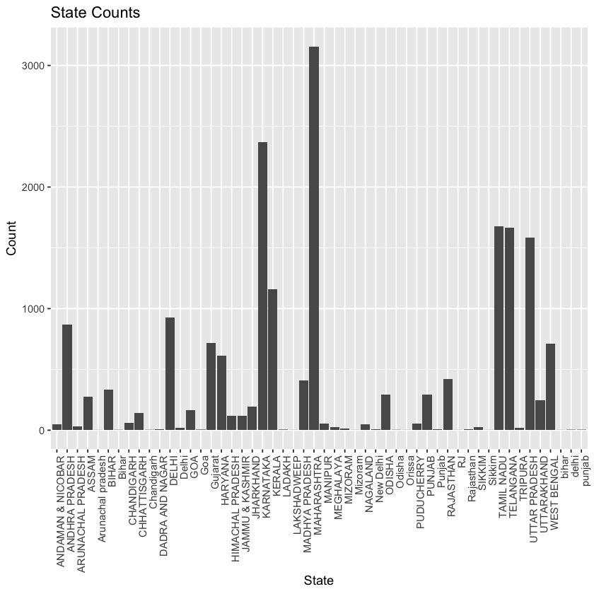

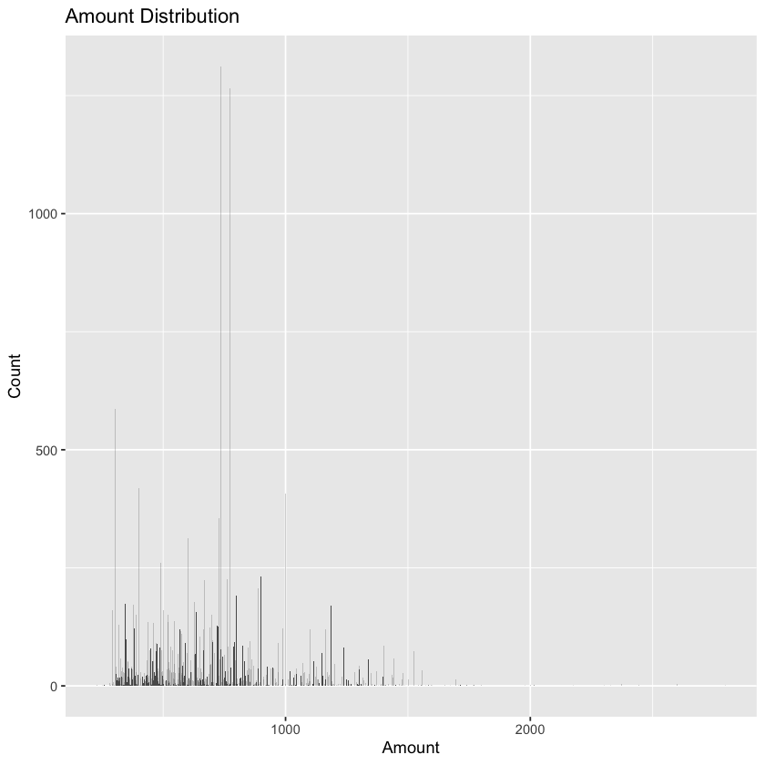

```r
# 1.
# Analyzing a categorical variable 'ship-state'
state_counts <- data_mutated %>%
  group_by(`ship-state`) %>%
  summarise(count = n(), .groups = "drop")

# Plotting the categorical variable
ggplot(state_counts, aes(x = `ship-state`, y = count)) +
  geom_bar(stat = "identity") +
  labs(title = "State Counts", x = "State", y = "Count") +
  theme(axis.text.x = element_text(angle = 90, hjust = 1))




# Analyzing a numerical variable 'Amount'
summary(data_mutated$Amount)

# Plotting the numerical variable
ggplot(data_mutated, aes(x = Amount)) +
  geom_histogram(binwidth = 1) +
  labs(title = "Amount Distribution", x = "Amount", y = "Count")
```

```
`geom_line()`: Each group consists of only one observation.
ℹ Do you need to adjust the group aesthetic?
```

A tibble: 5 × 3

| ship-state <chr> | total_amount <dbl> | total_orders <int> |
| --- | --- | --- |
| MAHARASHTRA | 2106917 | 3155 |
| KARNATAKA | 1595847 | 2369 |
| UTTAR PRADESH | 1152335 | 1583 |
| TELANGANA | 1143765 | 1664 |
| TAMIL NADU | 1084697 | 1675 |

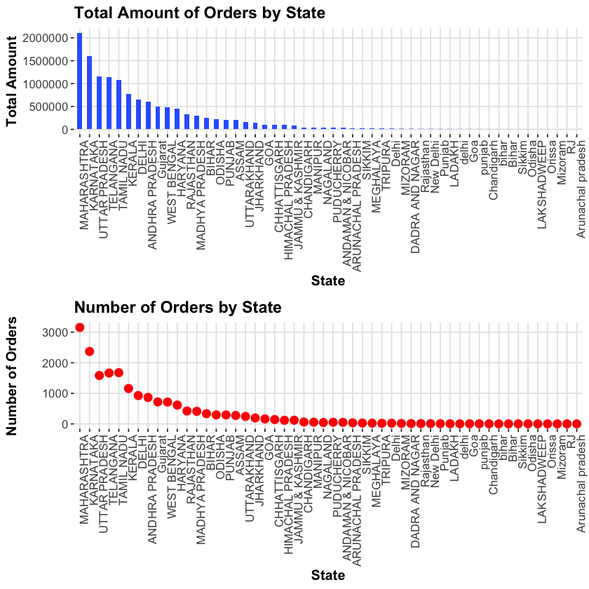

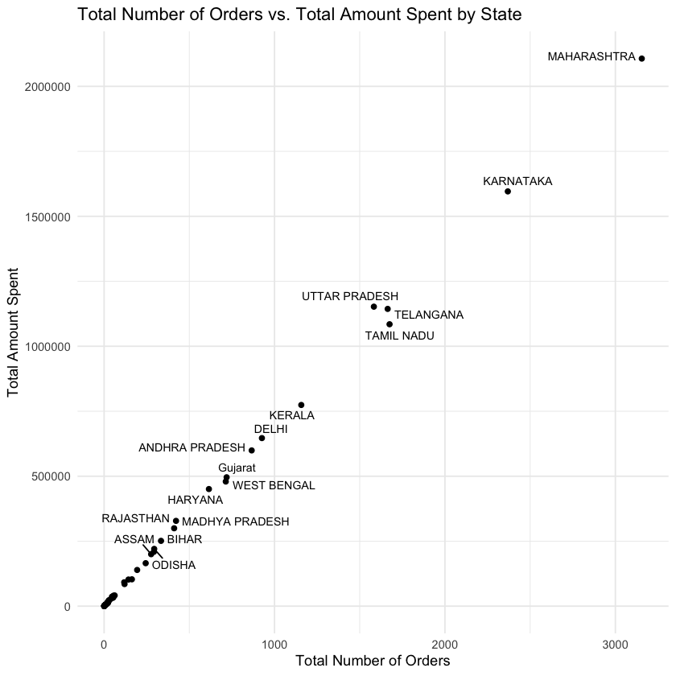

```r
# 2.

install.packages("cowplot")

library(ggplot2)

total_amount_order_by_state <- data_mutated %>%
  group_by(`ship-state`) %>%
  summarize(total_amount = sum(Amount, na.rm = TRUE),
            num_orders = n()) %>%
  arrange(desc(total_amount))  # Sort by descending order

# Create bar chart
bar_chart <- ggplot(total_amount_order_by_state, aes(x = reorder(`ship-state`, -total_amount), y = total_amount)) +
  geom_bar(stat = "identity", fill = "#3366FF", width = 0.5) +
  labs(title = "Total Amount of Orders by State",
       x = "State",
       y = "Total Amount") +
  theme(axis.text.x = element_text(angle = 90, hjust = 1),
        plot.title = element_text(size = 14, face = "bold"),
        axis.title = element_text(size = 12, face = "bold"),
        axis.text = element_text(size = 10),
        panel.background = element_blank(),
        panel.grid.major = element_line(color = "gray90"),
        panel.grid.minor = element_blank())

# Create line chart for number of orders
line_chart <- ggplot(total_amount_order_by_state, aes(x = reorder(`ship-state`, -total_amount), y = num_orders)) +
  geom_line(color = "red", size = 1.2) +
  geom_point(color = "red", size = 3) +
  labs(title = "Number of Orders by State",
       x = "State",
       y = "Number of Orders") +
  theme(axis.text.x = element_text(angle = 90, hjust = 1),
        plot.title = element_text(size = 14, face = "bold"),
        axis.title = element_text(size = 12, face = "bold"),
        axis.text = element_text(size = 10),
        panel.background = element_blank(),
        panel.grid.major = element_line(color = "gray90"),
        panel.grid.minor = element_blank())

# Combine the bar chart and line chart
combined_chart <- cowplot::plot_grid(bar_chart, line_chart, ncol = 1, align = "v")

# Print the combined chart
print(combined_chart)

# Load required packages
library(dplyr)
library(ggplot2)

# Calculate total amount and number of orders by state
total_amount_order_by_state <- data_mutated %>%
  group_by(`ship-state`) %>%
  summarize(total_amount = sum(Amount, na.rm = TRUE),
            total_orders = n()) %>%
  arrange(desc(total_amount)) %>%
  head(5)  # Select top 5 states

# Display the table
total_amount_order_by_state



install.packages("ggrepel")
library(ggrepel)
# Load required packages
library(dplyr)
library(ggplot2)
library(ggrepel)  # Added this line to load the ggrepel package

# Assuming you have a data frame named 'data_mutated' with columns 'ship-state', 'Amount', and 'OrderID'

data_mutated %>%
  group_by(`ship-state`) %>%
  summarize(total_amount = sum(Amount, na.rm = TRUE),
            total_orders = n()) %>%
  ggplot(aes(x = total_orders, y = total_amount, label = `ship-state`)) +
  geom_point() +
  geom_text_repel(aes(label = `ship-state`), size = 3) +
  labs(title = "Total Number of Orders vs. Total Amount Spent by State",
       x = "Total Number of Orders",
       y = "Total Amount Spent") +
  theme_minimal()
```

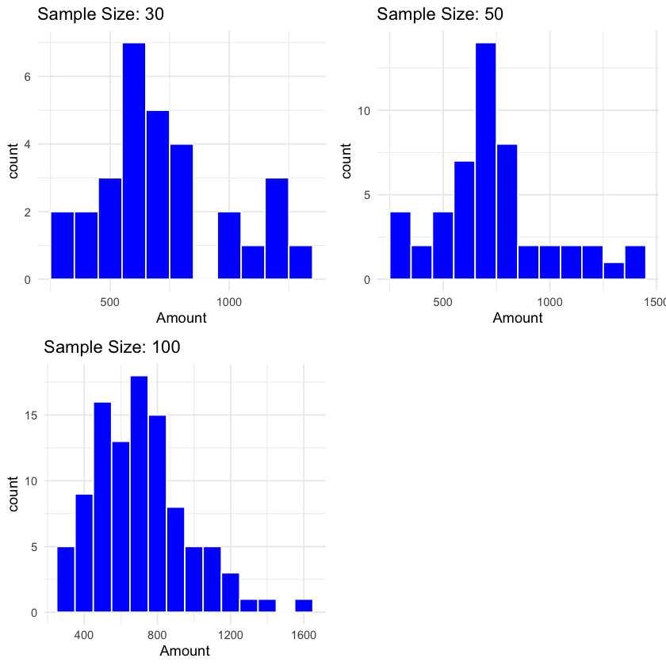

```r
# 3.
# Load required packages
library(dplyr)
library(ggplot2)

# Set the seed for reproducibility
set.seed(123)

# Choose the variable to analyze
variable <- data_mutated$Amount

# Define different sample sizes
sample_sizes <- c(30, 50, 100)

# Function to generate random samples and plot the distribution
generate_samples <- function(sample_size) {
  # Generate random sample
  sample <- sample(variable, size = sample_size, replace = TRUE)

  # Plot the distribution
  ggplot(data.frame(x = sample), aes(x = x)) +
    geom_histogram(binwidth = 100, fill = "blue", color = "white") +
    labs(title = paste("Sample Size:", sample_size), x = "Amount") +
    theme_minimal()
}

# Generate and plot random samples for different sample sizes
plots <- lapply(sample_sizes, generate_samples)

# Arrange the plots in a grid
gridExtra::grid.arrange(grobs = plots, ncol = 2)
```

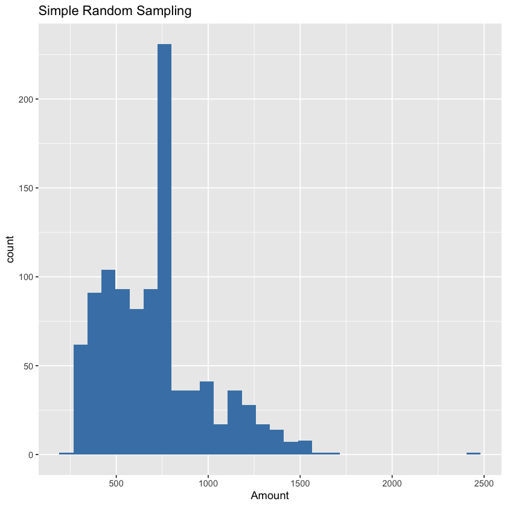

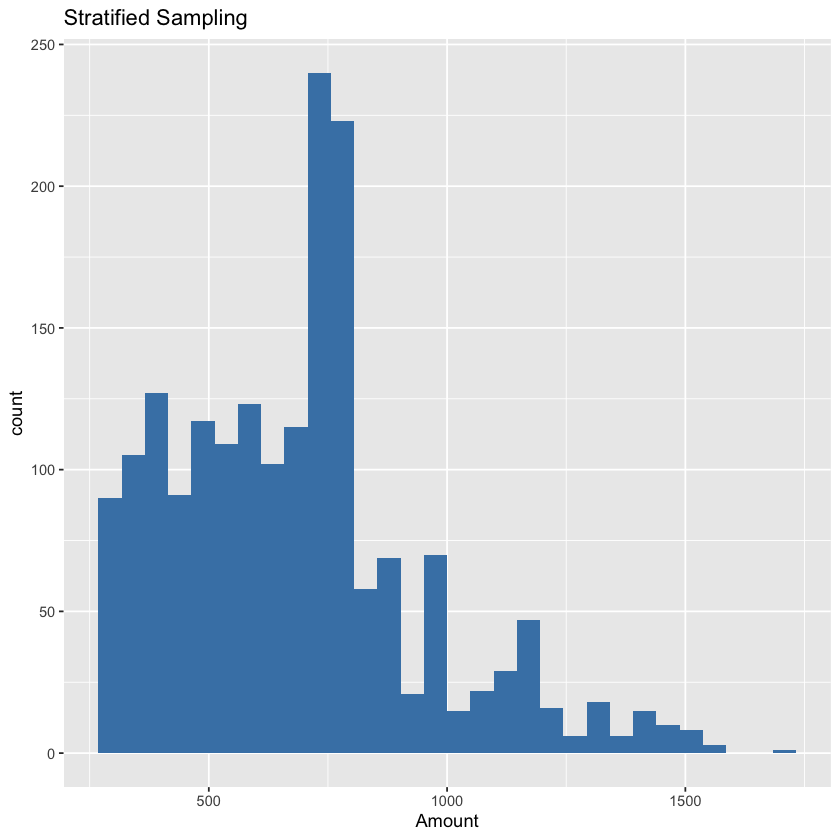

A tibble: 6 × 25

| index <dbl> | Order ID <chr> | Date <chr> | Status <chr> | Fulfilment <chr> | Sales Channel <chr> | ship-service-level <chr> | Style <chr> | SKU <chr> | Category <chr> | ⋯ | Amount <dbl> | ship-city <chr> | ship-state <chr> | ship-postal-code <dbl> | ship-country <chr> | promotion-ids <chr> | B2B <lgl> | fulfilled-by <chr> | Unnamed: 22 <lgl> | Amount_in_USD <dbl> |
| --- | --- | --- | --- | --- | --- | --- | --- | --- | --- | --- | --- | --- | --- | --- | --- | --- | --- | --- | --- | --- |
| 128555 | 405-9082290-8289116 | 06-01-22 | Shipped - Delivered to Buyer | Merchant | Amazon.in | Standard | JNE3549 | JNE3549-KR-XXL | kurta | ⋯ | 318 | HYDERABAD | TELANGANA | 500040 | IN | Amazon PLCC Free-Financing Universal Merchant AAT-WNKTBO3K27EJC,Amazon PLCC Free-Financing Universal Merchant AAT-QX3UCCJESKPA2,Amazon PLCC Free-Financing Universal Merchant AAT-5QQ7BIYYQEDN2,Amazon P… | FALSE | Easy Ship | FALSE | 349.8 |
| 128778 | 402-4708015-7152312 | 06-01-22 | Shipped - Delivered to Buyer | Merchant | Amazon.in | Standard | SET317 | SET317-KR-PP-M | Set | ⋯ | 1199 | DEHRADUN | UTTARAKHAND | 248001 | IN | Amazon PLCC Free-Financing Universal Merchant AAT-WNKTBO3K27EJC,Amazon PLCC Free-Financing Universal Merchant AAT-QX3UCCJESKPA2,Amazon PLCC Free-Financing Universal Merchant AAT-5QQ7BIYYQEDN2,Amazon P… | FALSE | Easy Ship | FALSE | 1318.9 |
| 63095 | 405-6386089-9425911 | 05-20-22 | Shipped - Delivered to Buyer | Merchant | Amazon.in | Standard | SET257 | SET257-KR-PP-M | Set | ⋯ | 568 | MUMBAI | MAHARASHTRA | 400042 | IN | Amazon PLCC Free-Financing Universal Merchant AAT-WNKTBO3K27EJC,Amazon PLCC Free-Financing Universal Merchant AAT-QX3UCCJESKPA2,Amazon PLCC Free-Financing Universal Merchant AAT-5QQ7BIYYQEDN2,Amazon P… | FALSE | Easy Ship | FALSE | 624.8 |
| 59235 | 408-5449115-7037914 | 05-24-22 | Shipped - Delivered to Buyer | Merchant | Amazon.in | Standard | J0003 | J0003-SET-M | Set | ⋯ | 696 | HYDERABAD | TELANGANA | 500019 | IN | Amazon PLCC Free-Financing Universal Merchant AAT-WNKTBO3K27EJC,Amazon PLCC Free-Financing Universal Merchant AAT-QX3UCCJESKPA2,Amazon PLCC Free-Financing Universal Merchant AAT-5QQ7BIYYQEDN2,Amazon P… | FALSE | Easy Ship | FALSE | 765.6 |
| 64120 | 405-7619089-2151514 | 05-19-22 | Shipped - Delivered to Buyer | Merchant | Amazon.in | Standard | JNE3801 | JNE3801-KR-XXXL | kurta | ⋯ | 771 | BEAWAR | RAJASTHAN | 305901 | IN | Amazon PLCC Free-Financing Universal Merchant AAT-WNKTBO3K27EJC,Amazon PLCC Free-Financing Universal Merchant AAT-QX3UCCJESKPA2,Amazon PLCC Free-Financing Universal Merchant AAT-5QQ7BIYYQEDN2,Amazon P… | FALSE | Easy Ship | FALSE | 848.1 |
| 94356 | 171-8284488-9410712 | 06-26-22 | Shipped - Picked Up | Merchant | Amazon.in | Standard | MEN5010 | MEN5010-KR-XXL | kurta | ⋯ | 618 | MURWARA KATNI | MADHYA PRADESH | 483501 | IN | Amazon PLCC Free-Financing Universal Merchant AAT-WNKTBO3K27EJC,Amazon PLCC Free-Financing Universal Merchant AAT-QX3UCCJESKPA2,Amazon PLCC Free-Financing Universal Merchant AAT-5QQ7BIYYQEDN2,Amazon P… | FALSE | Easy Ship | FALSE | 679.8 |

A grouped_df: 6 × 25

| index <dbl> | Order ID <chr> | Date <chr> | Status <chr> | Fulfilment <chr> | Sales Channel <chr> | ship-service-level <chr> | Style <chr> | SKU <chr> | Category <chr> | ⋯ | Amount <dbl> | ship-city <chr> | ship-state <chr> | ship-postal-code <dbl> | ship-country <chr> | promotion-ids <chr> | B2B <lgl> | fulfilled-by <chr> | Unnamed: 22 <lgl> | Amount_in_USD <dbl> |
| --- | --- | --- | --- | --- | --- | --- | --- | --- | --- | --- | --- | --- | --- | --- | --- | --- | --- | --- | --- | --- |
| 88613 | 402-9289095-5625954 | 05-02-22 | Shipped - Delivered to Buyer | Merchant | Amazon.in | Standard | JNE3722 | JNE3722-KR-L | kurta | ⋯ | 280 | COIMBATORE | TAMIL NADU | 641041 | IN | Amazon PLCC Free-Financing Universal Merchant AAT-WNKTBO3K27EJC,Amazon PLCC Free-Financing Universal Merchant AAT-QX3UCCJESKPA2,Amazon PLCC Free-Financing Universal Merchant AAT-5QQ7BIYYQEDN2,Amazon P… | FALSE | Easy Ship | FALSE | 308.0 |
| 77901 | 171-2837732-0909167 | 05-08-22 | Shipped - Delivered to Buyer | Merchant | Amazon.in | Standard | JNE3721 | JNE3721-KR-L | kurta | ⋯ | 292 | Allahabad | UTTAR PRADESH | 212107 | IN | Amazon PLCC Free-Financing Universal Merchant AAT-WNKTBO3K27EJC,Amazon PLCC Free-Financing Universal Merchant AAT-QX3UCCJESKPA2,Amazon PLCC Free-Financing Universal Merchant AAT-5QQ7BIYYQEDN2,Amazon P… | FALSE | Easy Ship | FALSE | 321.2 |
| 80089 | 171-2945562-6028342 | 05-07-22 | Shipped - Delivered to Buyer | Merchant | Amazon.in | Standard | JNE3745 | JNE3745-KR-L | kurta | ⋯ | 292 | HYDERABAD | TELANGANA | 502032 | IN | Amazon PLCC Free-Financing Universal Merchant AAT-WNKTBO3K27EJC,Amazon PLCC Free-Financing Universal Merchant AAT-QX3UCCJESKPA2,Amazon PLCC Free-Financing Universal Merchant AAT-5QQ7BIYYQEDN2,Amazon P… | FALSE | Easy Ship | FALSE | 321.2 |
| 109093 | 407-1344657-5550704 | 06-14-22 | Shipped - Delivered to Buyer | Merchant | Amazon.in | Standard | JNE3721 | JNE3721-KR-XL | kurta | ⋯ | 292 | INDORE | MADHYA PRADESH | 452014 | IN | Amazon PLCC Free-Financing Universal Merchant AAT-WNKTBO3K27EJC,Amazon PLCC Free-Financing Universal Merchant AAT-QX3UCCJESKPA2,Amazon PLCC Free-Financing Universal Merchant AAT-5QQ7BIYYQEDN2,Amazon P… | FALSE | Easy Ship | FALSE | 321.2 |
| 79481 | 171-0883556-3604326 | 05-07-22 | Shipped - Delivered to Buyer | Merchant | Amazon.in | Standard | JNE3703 | JNE3703-KR-S | kurta | ⋯ | 292 | NUZVID | ANDHRA PRADESH | 521201 | IN | Amazon PLCC Free-Financing Universal Merchant AAT-WNKTBO3K27EJC,Amazon PLCC Free-Financing Universal Merchant AAT-QX3UCCJESKPA2,Amazon PLCC Free-Financing Universal Merchant AAT-5QQ7BIYYQEDN2,Amazon P… | FALSE | Easy Ship | FALSE | 321.2 |
| 126319 | 408-9845701-0891563 | 06-02-22 | Shipped - Delivered to Buyer | Merchant | Amazon.in | Standard | JNE3703 | JNE3703-KR-XL | kurta | ⋯ | 292 | GUNTUR | ANDHRA PRADESH | 522006 | IN | Amazon PLCC Free-Financing Universal Merchant AAT-WNKTBO3K27EJC,Amazon PLCC Free-Financing Universal Merchant AAT-QX3UCCJESKPA2,Amazon PLCC Free-Financing Universal Merchant AAT-5QQ7BIYYQEDN2,Amazon P… | FALSE | Easy Ship | FALSE | 321.2 |

A tibble: 6 × 25

| index <dbl> | Order ID <chr> | Date <chr> | Status <chr> | Fulfilment <chr> | Sales Channel <chr> | ship-service-level <chr> | Style <chr> | SKU <chr> | Category <chr> | ⋯ | Amount <dbl> | ship-city <chr> | ship-state <chr> | ship-postal-code <dbl> | ship-country <chr> | promotion-ids <chr> | B2B <lgl> | fulfilled-by <chr> | Unnamed: 22 <lgl> | Amount_in_USD <dbl> |
| --- | --- | --- | --- | --- | --- | --- | --- | --- | --- | --- | --- | --- | --- | --- | --- | --- | --- | --- | --- | --- |
| 49139 | 408-7891501-1393915 | 05-31-22 | Shipped - Delivered to Buyer | Merchant | Amazon.in | Standard | J0280 | J0280-SKD-M | Set | ⋯ | 1556 | BENGALURU | KARNATAKA | 560028 | IN | Amazon PLCC Free-Financing Universal Merchant AAT-WNKTBO3K27EJC,Amazon PLCC Free-Financing Universal Merchant AAT-QX3UCCJESKPA2,Amazon PLCC Free-Financing Universal Merchant AAT-5QQ7BIYYQEDN2,Amazon P… | FALSE | Easy Ship | FALSE | 1711.6 |
| 49573 | 403-2388768-9793909 | 05-31-22 | Shipped - Delivered to Buyer | Merchant | Amazon.in | Standard | J0280 | J0280-SKD-XXL | Set | ⋯ | 1556 | PUNE | MAHARASHTRA | 412307 | IN | Amazon PLCC Free-Financing Universal Merchant AAT-WNKTBO3K27EJC,Amazon PLCC Free-Financing Universal Merchant AAT-QX3UCCJESKPA2,Amazon PLCC Free-Financing Universal Merchant AAT-5QQ7BIYYQEDN2,Amazon P… | FALSE | Easy Ship | FALSE | 1711.6 |
| 49618 | 408-3461842-2081920 | 05-31-22 | Shipped - Delivered to Buyer | Merchant | Amazon.in | Standard | J0280 | J0280-SKD-XXL | Set | ⋯ | 1556 | LUCKNOW | UTTAR PRADESH | 226016 | IN | Amazon PLCC Free-Financing Universal Merchant AAT-WNKTBO3K27EJC,Amazon PLCC Free-Financing Universal Merchant AAT-QX3UCCJESKPA2,Amazon PLCC Free-Financing Universal Merchant AAT-5QQ7BIYYQEDN2,Amazon P… | FALSE | Easy Ship | FALSE | 1711.6 |
| 51185 | 171-9727600-3972312 | 05-30-22 | Shipped - Delivered to Buyer | Merchant | Amazon.in | Standard | SET340 | SET340-KR-NP-S | Set | ⋯ | 799 | LUCKNOW | UTTAR PRADESH | 226029 | IN | Amazon PLCC Free-Financing Universal Merchant AAT-WNKTBO3K27EJC,Amazon PLCC Free-Financing Universal Merchant AAT-QX3UCCJESKPA2,Amazon PLCC Free-Financing Universal Merchant AAT-5QQ7BIYYQEDN2,Amazon P… | FALSE | Easy Ship | FALSE | 878.9 |
| 51343 | 405-5091201-8274756 | 05-30-22 | Shipped - Delivered to Buyer | Merchant | Amazon.in | Standard | J0280 | J0280-SKD-XXXL | Set | ⋯ | 1556 | AMLA | MADHYA PRADESH | 460553 | IN | Amazon PLCC Free-Financing Universal Merchant AAT-WNKTBO3K27EJC,Amazon PLCC Free-Financing Universal Merchant AAT-QX3UCCJESKPA2,Amazon PLCC Free-Financing Universal Merchant AAT-5QQ7BIYYQEDN2,Amazon P… | FALSE | Easy Ship | FALSE | 1711.6 |
| 51396 | 408-6348142-3477131 | 05-30-22 | Shipped - Delivered to Buyer | Merchant | Amazon.in | Standard | SET340 | SET340-KR-NP-XS | Set | ⋯ | 799 | Belur | WEST BENGAL | 711227 | IN | Amazon PLCC Free-Financing Universal Merchant AAT-WNKTBO3K27EJC,Amazon PLCC Free-Financing Universal Merchant AAT-QX3UCCJESKPA2,Amazon PLCC Free-Financing Universal Merchant AAT-5QQ7BIYYQEDN2,Amazon P… | FALSE | Easy Ship | FALSE | 878.9 |

```
   Min. 1st Qu.  Median    Mean 3rd Qu.    Max.
  229.0   487.0   699.0   705.9   799.0  2442.0
```

```
   Min. 1st Qu.  Median    Mean 3rd Qu.    Max.
  280.0   486.0   690.0   683.5   786.0  1695.0
```

```
   Min. 1st Qu.  Median    Mean 3rd Qu.    Max.
  348.0   799.0   799.0   847.2   799.0  1556.0
```

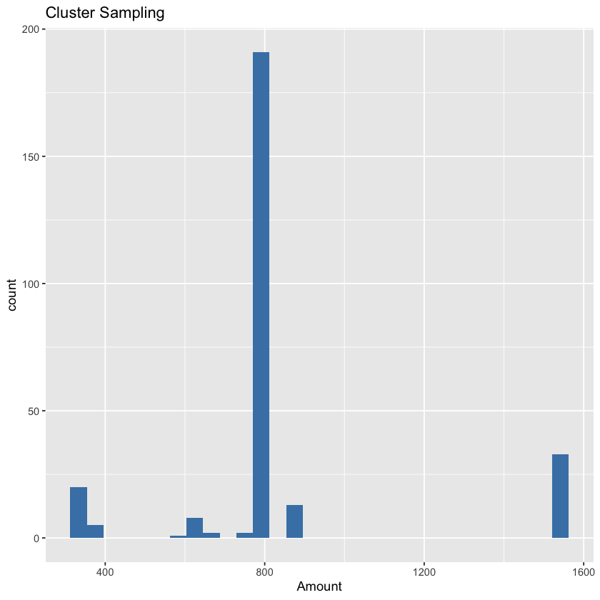

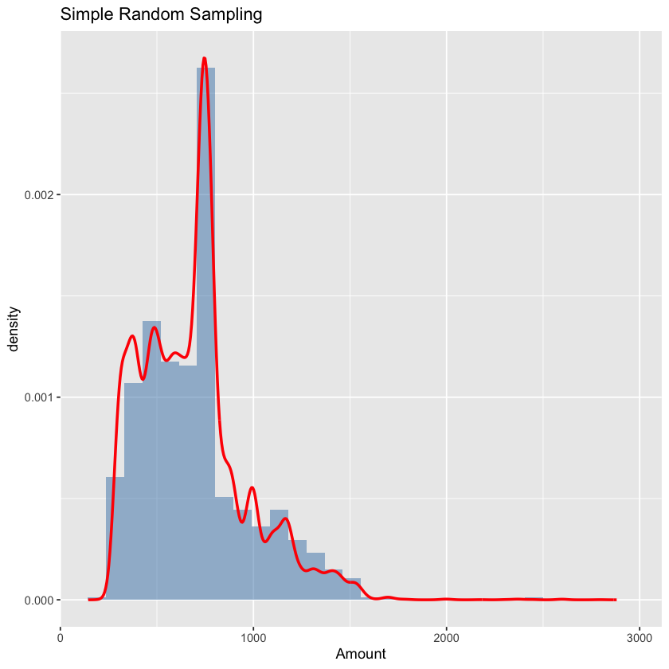

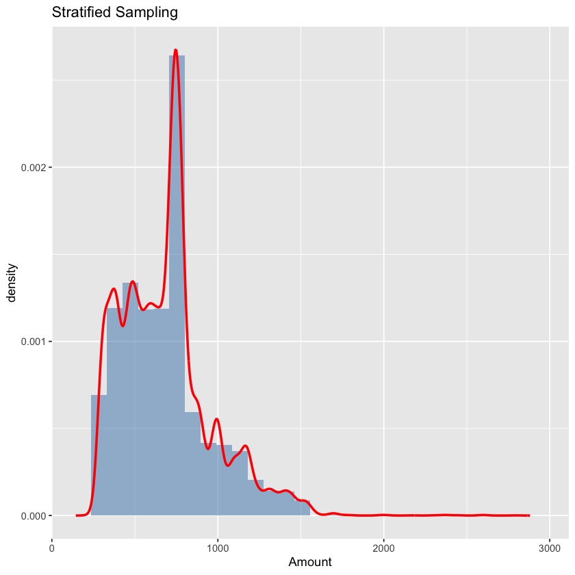

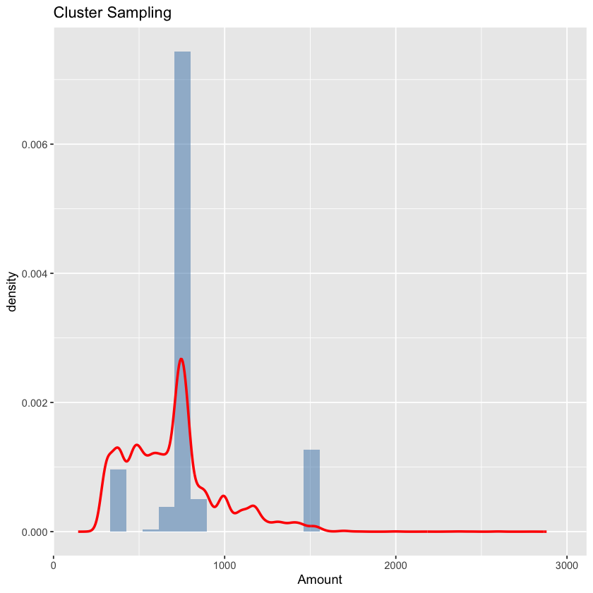

```r
# Simple Random Sampling
set.seed(123)
sample_random <- data_mutated %>% sample_n(1000)

# Stratified Sampling - based on 'amount'
set.seed(123)
sample_stratified <- data_mutated %>%
  group_by(`Amount`) %>%
  sample_frac(size = 0.1)

# Cluster Sampling - assuming 10 clusters chosen
set.seed(123)
chosen_clusters <- unique(data_mutated$`Amount`) %>% sample(10)
sample_cluster <- data_mutated %>% filter(`Amount` %in% chosen_clusters)

# Load required libraries
library(ggplot2)

# Simple Random Sampling
ggplot(sample_random, aes(x = Amount)) +
  geom_histogram(bins = 30, fill = 'steelblue') +
  ggtitle("Simple Random Sampling")

# Stratified Sampling
ggplot(sample_stratified, aes(x = Amount)) +
  geom_histogram(bins = 30, fill = 'steelblue') +
  ggtitle("Stratified Sampling")

# Cluster Sampling
ggplot(sample_cluster, aes(x = Amount)) +
  geom_histogram(bins = 30, fill = 'steelblue') +
  ggtitle("Cluster Sampling")


# Display top rows of each sampled data
head(sample_random)
head(sample_stratified)
head(sample_cluster)
# Summary of 'Amount' for each sampling method
summary(sample_random$Amount)
summary(sample_stratified$Amount)
summary(sample_cluster$Amount)


# Calculate density of 'Amount' in original dataset
amount_density <- density(data_mutated$Amount)
density_data <- data.frame(x = amount_density$x, y = amount_density$y)

# Simple Random Sampling with Density
ggplot(sample_random, aes(x = Amount)) +
  geom_histogram(aes(y = after_stat(density)), bins = 30, fill = 'steelblue', alpha = 0.5) +
  geom_line(data = density_data, aes(x = x, y = y), color = "red", size = 1) +
  ggtitle("Simple Random Sampling")

# Stratified Sampling with Density
ggplot(sample_stratified, aes(x = Amount)) +
  geom_histogram(aes(y = after_stat(density)), bins = 30, fill = 'steelblue', alpha = 0.5) +
  geom_line(data = density_data, aes(x = x, y = y), color = "red", size = 1) +
  ggtitle("Stratified Sampling")

# Cluster Sampling with Density
ggplot(sample_cluster, aes(x = Amount)) +
  geom_histogram(aes(y = after_stat(density)), bins = 30, fill = 'steelblue', alpha = 0.5) +
  geom_line(data = density_data, aes(x = x, y = y), color = "red", size = 1) +
  ggtitle("Cluster Sampling")
```

Simple Random Sampling: In this sampling method, we randomly select a fixed-size sample from the entire dataset. This can be achieved using the sample() function in R. If we use simple random sampling to represent the entire dataset, our conclusions may be relatively reliable because each observation has an equal chance of being selected.

Cluster Sampling: In this sampling method, we divide the dataset into different clusters and then select all observations from a portion of clusters as the sample. This can be implemented using the corresponding functions in R. If we use cluster sampling to represent the entire dataset, our conclusions may be influenced by the similarity within clusters, so caution is needed when drawing conclusions.

In conclusion, the choice of sampling method directly impacts our conclusions. When using sampling methods to represent the entire dataset, we should consider the advantages and limitations of each method. Simple random sampling may provide relatively reliable conclusions, while stratified sampling can offer more representative conclusions. Cluster sampling may be influenced by the similarity within clusters, so it should be used with caution. The ultimate conclusions should be based on the chosen sampling method and the characteristics and objectives of the dataset itself.

```
	Pearson's product-moment correlation

data:  data_mutated$Qty and data_mutated$Price_per_item
t = -2.031, df = 18920, p-value = 0.04227
alternative hypothesis: true correlation is not equal to 0
95 percent confidence interval:
 -0.0290064242 -0.0005156042
sample estimates:
        cor
-0.01476401
```

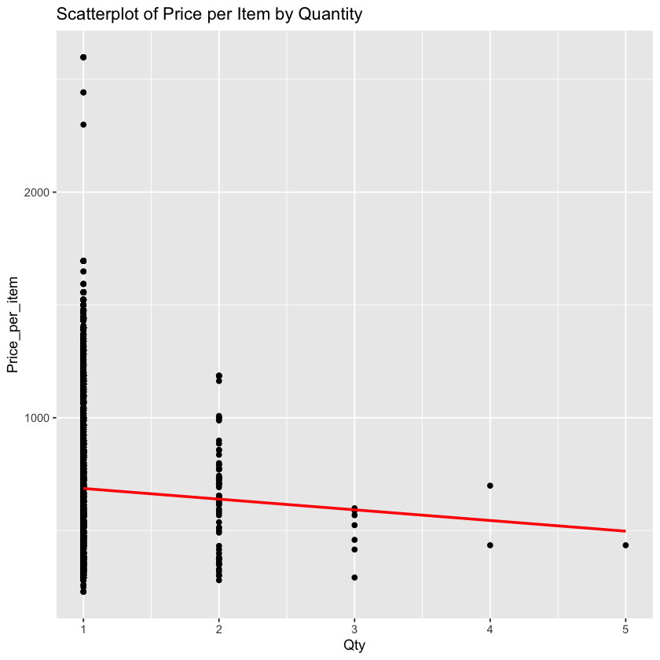

```r
# 5.

# Create a new variable for price per item
data_mutated <- data_mutated %>%
  mutate(Price_per_item = Amount / Qty)

# Visualize relationship between Qty and Price_per_item
ggplot(data_mutated, aes(x = Qty, y = Price_per_item)) +
  geom_point() +
  geom_smooth(method = "lm", se = FALSE, color = "red") +
  ggtitle("Scatterplot of Price per Item by Quantity")

# Calculate correlation
cor.test(data_mutated$Qty, data_mutated$Price_per_item, method = "pearson")
```

This code first creates a new variable Price_per_item in your dataframe. It then generates a scatterplot of Price_per_item against Qty. The geom_smooth() function adds a line of best fit to the plot, with method = "lm" specifying a linear model (i.e., a straight line).

Finally, it calculates the Pearson correlation between Qty and Price_per_item. A negative correlation would suggest that as quantity increases, the price per item decreases, which would support your hypothesis. However, the actual relationship may be more complex and could require more advanced statistical modeling to fully understand.